# Análisis de sentimiento e interacción en los Tweets de Pedro Castillo Terrones (@PedroCastilloTe)

Josue Huaman

18/10/2022

## Introducción

Este estudio pretende descubrir la carga sentimental que poseen los tweets de Pedro Castillo y cuáles logran una mayor interacción con la población, para ello utilizaremos el entorno y lenguaje de programación R.

## Herramientas

- R
- rtweet
- ggplot2

## Recolección de datos

Los datos serán obtenidos mediante la API de Twitter con la librería `rtweet`, para ello es necesario registrarse en la aplicación y obtener las credenciales en la sección desarrolladores, de forma predeterminada solo se puede acceder a información pública de los tweets y usuarios.

```r
twitter_tokens <- create_token(app = "", consumer_key = "", consumer_secret = "")
```

Una vez autenticados pasamos a recolectar los tweets.

```r
castillovar <- get_timeline("PedroCastilloTe", n = 4000)
```

Seleccionaremos la variable de interés y guardamos los datos en un archivo .csv:

```r
castillovar <- castillovar[c("created_at", "text", "favorite_count", "retweet_count")]
```

```r
num_rows = nrow(castillovar)

# creating ID column vector
X <- c(1:num_rows)

# binding id column to the data frame
castillovar <- cbind(X , castillovar)
```

```r
write_as_csv(castillovar, "castillovar.csv")
```

Con `readr` cargamos el archivo .csv

```r
library(readr)
castillovar <- read_csv("castillovar.csv")
castillovar
```

## Preparación de los datos

Una pieza central para un análisis de texto (*text mining*) es el tokenizado. La tokenización es una forma de separar un fragmento de texto en unidades más pequeñas llamadas tokens. Aquí, los tokens pueden ser palabras, caracteres o subpalabras. Por lo tanto, la tokenización se puede clasificar ampliamente en 3 tipos: tokenización de palabra, carácter y subpalabra (caracteres n-grama).

Utilizaremos `string` y `stringr` para la manipulación de caracteres, `dplyr` para la manipulación del data frame, `magrittr` para el uso de *pipes* y `tidytext` para el tokenizado y el análisis de texto.

```r
library(stringi)
library(stringr)
library(dplyr)
library(magrittr)
library(tidytext)

# Quitamos los acentos a los tweets.

castillovar$text <- stri_trans_general(castillovar$text, "Latin-ASCII")

# Limpiamos la variable text de algunos elementos innecesarios y  tokenizamos.

replace_reg <- "https://t.co/[A-Za-z\\d]+|http://[A-Za-z\\d]+|&amp;|&lt;|&gt;|RT|https"
unnest_reg <- "([^A-Za-z_\\d#@']|'(?![A-Za-z_\\d#@]))"
castillovar_t <- castillovar %>%
  filter(!str_detect(text, "^RT")) %>%
  mutate(text = str_replace_all(text, replace_reg, "")) %>%
  unnest_tokens(word, text, token = "regex", pattern = unnest_reg)  # Tokenizado
rm(replace_reg, unnest_reg)
```

El resultado es DataFrame más grande, de 42751 observaciones, Donde se reemplaza la columna (variable) *text* por *word*, manteniendo la variable *X* como ID:

```r
str(castillovar_t)
```

```
tibble [42,751 x 5] (S3: tbl_df/tbl/data.frame)
 $ X             : num [1:42751] 1 1 1 1 1 1 1 1 1 1 ...
 $ created_at    : POSIXct[1:42751], format: "2022-10-18 22:21:14" "2022-10-18 22:21:14" "2022-10-18 22:21:14" ...
 $ favorite_count: num [1:42751] 0 0 0 0 0 0 0 0 0 0 ...
 $ retweet_count : num [1:42751] 199 199 199 199 199 199 199 199 199 199 ...
 $ word          : chr [1:42751] "u" "0001f534" "#ahora" "numeroso" ...
```

El siguiente problema es que las palabras con mayor frecuencia son, como era de esperarse, artículos, preposiciones, conjunciones, y otros similares:

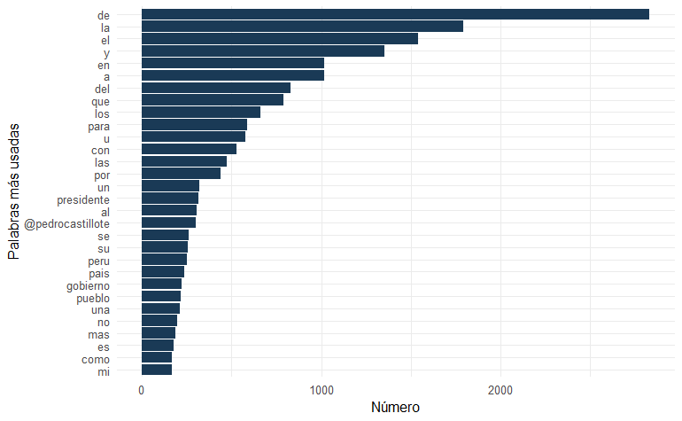

```r
library(ggplot2)
freq1 <- castillovar_t %>%
        count(word, sort = TRUE)
head(freq1, n = 30) %>%
        ggplot(aes(reorder(word, n), n)) +
        geom_bar(stat="identity", fill="#1a3a56") +
        coord_flip() +
        xlab("Palabras más usadas") +
        ylab("Número") +
        theme_minimal()
```

Esas palabras no agregan ninguna información relevante para entender la polaridad de los *sentiments*, son “palabras vacías” que debemos filtrar. Para ello necesitamos una lista de ese tipo de palabras en español que extraeremos del paquete `stopwords`:

```r
library(stopwords)

#crear una lista de palabras vacias en español
stopwords_ES <- tibble(stopwords("spanish"))
colnames(stopwords_ES) <- "word"

#Agregamos algunas palabras vacias adicionales (lugares y monedas, etc.)
custom_stop <- tibble(word = c("lima", "cajamarca", "peru", "0001f134","0001f534", "dolar", "sol", "derecha", "u", "@pedrocastillote", "primero", "0001f1ea", "0001f1f5", "mas", "presidente","hoy", "fe0f", "#siempreconelpueblo","#palabrademaestro"))
stopwords_ES <- bind_rows(custom_stop, stopwords_ES)
rm(custom_stop)

#filtrado con la lista de palabras vacias
castillovar_tf <- castillovar_t %>%
 filter(!word %in% stopwords_ES$word,
         str_detect(word, "[a-z]"))
str(castillovar_tf)
```

```
tibble [20,983 x 5] (S3: tbl_df/tbl/data.frame)
 $ X             : num [1:20983] 1 1 1 1 1 1 1 1 1 1 ...
 $ created_at    : POSIXct[1:20983], format: "2022-10-18 22:21:14" "2022-10-18 22:21:14" "2022-10-18 22:21:14" ...
 $ favorite_count: num [1:20983] 0 0 0 0 0 0 0 0 0 0 ...
 $ retweet_count : num [1:20983] 199 199 199 199 199 199 199 199 199 199 ...
 $ word          : chr [1:20983] "#ahora" "numeroso" "grupo" "licenciados" ...
```

Ahora sí podemos observar las palabras más utilizadas por Pedro Castillo (@PedroCastilloTe):

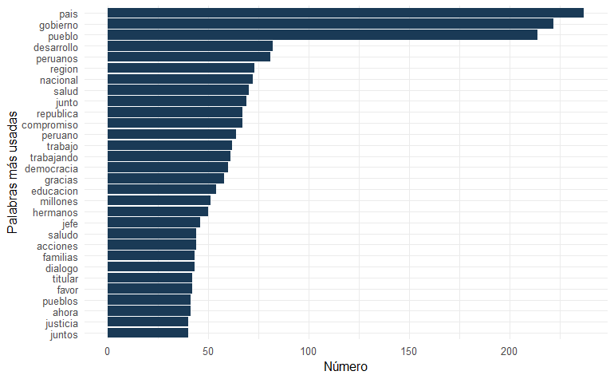

```r
freq2 <- castillovar_tf %>%
        count(word, sort = TRUE)
head(freq2, n = 30) %>%
        ggplot(aes(reorder(word, n), n)) +
        geom_bar(stat="identity", fill="#1a3a56") +
        coord_flip() +
        xlab("Palabras más usadas") +
        ylab("Número")+
        theme_minimal()
```

## Análisis de datos

El análisis de sentimiento nos permite aproximarnos a la intención emocional de los tweets que lanza el presidente Pedro Castillo. Este tipo de análisis puede basarse en el análisis de palabras o relaciones de palabras (n-gramas) y se pueden evaluar diferentes escalas de sentimiento (binarias, ponderadas, etc.).

Elegimos el enfoque de “bolsa de palabras”, el nivel del unigrama y la escala binaria, como una primera aproximación expedita. Ahora bien, existen diversos métodos para evaluar los *sentiments* en los textos, desde la anotación manual hasta el uso de *machine learning*, pero aquí utilizaremos el método basado en diccionario (Silge y Robinson 2017).

Este método conste en utilizar un diccionario en formato *clave:valor* para evaluar cada palabra. Se considera al tweet como una combinación de palabras individuales que tienen una carga emocional y la proporción de esas palabras nos da el sentimiento general del tweet, como posteriormente reflejaremos en un indice de sentimiento.

Los diccionarios para análisis de sentimiento en español son escasos y poco desarrollados. Después de una larga búsqueda pudimos encontrar el diccionario [iSol](http://timm.ujaen.es/recursos/isol/) que está formado por 8135 palabras, 2.509 positivas y 5.626 negativas, dejando a un lado las palabras emocionalmente neutras. Este diccionario a su vez está basado en otro diccionario en inglés bastante testeado como es el de [Bing Liu](https://www.cs.uic.edu/~liub/FBS/sentiment-analysis.html), siendo una traducción especializada y mejorada.

```r
#cargamos y adecuamos el diccionario al formato requerido.
negativas <- read_csv("isol/negativas_mejorada.csv", col_names = "word") %>%
  mutate(sentiment = "negativo")
positivas <- read_csv("isol/positivas_mejorada.csv", col_names = "word") %>%
  mutate(sentiment = "positivo")
bingES <- bind_rows(negativas, positivas)
rm(negativas, positivas)

# Quitamos los acentos.
bingES$word <- stri_trans_general(bingES$word, "Latin-ASCII")
bingES
```

| word | sentiment |
| --- | --- |
| anicos | negativo |
| abandonada | negativo |
| abandonadas | negativo |
| abandonado | negativo |
| abandonados | negativo |
| abandonar | negativo |
| abandonos | negativo |
| abarrotada | negativo |
| abarrotadas | negativo |
| abarrotado | negativo |

[output cut: 990 more lines]

Una primera prueba del diccionario que realizaremos será comprobar qué porcentaje de las palabras únicas utilizadas por @PedroCastilloTe clasifica este diccionario:

```r
# palabras únicas usadas por @PedroCastilloTe
castillo_w <- unique(castillovar_tf$word) %>% tibble()
colnames(castillo_w) <- "word"
print(paste("Palabras únicas usadas por @PedroCastilloTe:", length(castillo_w$word)))
```

```
[1] "Palabras únicas usadas por @PedroCastilloTe: 6295"
```

```r
# palabras en el diccionario
dic_w <- bingES$word
print(paste("Palabras en el diccionario:", length(dic_w)))
```

```
[1] "Palabras en el diccionario: 8135"
```

```r
# palabras clasificadas
castillo_wc <- castillo_w %>% filter(word %in% dic_w)
print(paste("Palabras clasificadas:", length(castillo_wc$word)))
```

```
[1] "Palabras clasificadas: 688"
```

```r
# palabras no clasificadas
castillo_uc <- castillo_w %>% filter(!word %in% dic_w)
print(paste("Palabras no clasificadas:", length(castillo_uc$word)))
```

```
[1] "Palabras no clasificadas: 5607"
```

```r
# Porcentaje de palabras clasificadaas
por_w <- (length(castillo_wc$word) / length(castillo_w$word)) * 100
print(paste("Porcentaje de palabras clasificadaas:", por_w, "%"))
```

```
[1] "Porcentaje de palabras clasificadaas: 10.9293089753773 %"
```

Palabras no clasificadas

```r
castillo_uc
```

| word |
| --- |
| #ahora |
| numeroso |
| grupo |
| licenciados |
| miembros |
| fuerzas |
| armadas |
| encuentran |
| patio |
| honor |

[output cut: 990 more lines]

El diccionario clasificó el 10.91% de las palabras. Lo ideal es que el diccionario se aproxime al 20% de las palabras siguiendo la ley de Zipf, por lo que efectuaremos unas modificaciones.

Al revisar el diccionario encontramos tres problemas:

- Primero, si bien contiene muchas palabras con clara carga sentimental, en ocasiones no contiene todas sus flexiones.
- Segundo, dado que es un diccionario general, no captura algunas particularidades del discurso político del presidente, particularmente su discurso nacionalista.
- Tercero, existen palabras polarizadas que sirven para indicar el sentimiento frente a un producto o servicio, pero no tienen efectividad en temas políticos.

Para el primer problema añadiremos flexiones basadas ya en las palabras existentes en el diccionario, para el segundo añadiremos las palabras politizadas más utilizadas, evaluando su polaridad en un intento de un diccionario político inicial, y para el tercero retiraremos las palabras no apropiadas:

```r
# Añadiendo flexiones y otras palabras polarizadas
flex_dic <- read_csv("CastilloNC.csv", col_names = c("word", "sentiment"))
flex_dic <- flex_dic %>% filter(str_detect(sentiment, "positivo|negativo"))
flex_dic
```

| word | sentiment |
| --- | --- |
| abandona | negativo |
| abandonamos | negativo |
| abandonaremos | negativo |
| abandonaron | negativo |
| abandono | negativo |
| abarataremos | positivo |
| aberracion | negativo |
| abominables | negativo |
| abusar | negativo |
| abusaron | negativo |

[output cut: 568 more lines]

```r
bingESmod <- bind_rows(bingES, flex_dic)
bingESmod
```

| word | sentiment |
| --- | --- |
| anicos | negativo |
| abandonada | negativo |
| abandonadas | negativo |
| abandonado | negativo |
| abandonados | negativo |
| abandonar | negativo |
| abandonos | negativo |
| abarrotada | negativo |
| abarrotadas | negativo |
| abarrotado | negativo |

[output cut: 990 more lines]

Añadiendo palabras politizadas

```r
tribble(
  ~word, ~sentiment,
  "pueblo", "positivo",
  "eeuu", "negativo",
  "estadounidense", "negativo",
  "estadounidenses", "negativo",
  "chile", "negativo",
  "imperio", "negativo",
  "imperios", "negativo",
  "imperial", "negativo",
  "imperiales", "negativo",
  "imperialismo", "negativo",
  "capitalismo", "negativo",
  "capitalista", "negativo",
  "procapitalista", "negativo",
  "capitalización", "negativo",
  "neoliberal", "negativo",
  "neoliberales", "negativo",
  "neoliberalismo", "negativo",
  "neocolonial", "negativo",
  "neocoloniales", "negativo",
  "neocolonialismo", "negativo",
  "recolonizacion", "negativo",
  "oligarquia", "negativo",
  "oligarquias", "negativo",
  "oligarca", "negativo",
  "oligarcas", "negativo",
  "oligarquica", "negativo",
  "oligarquicos", "negativo",
  "derecha", "negativo",
  "derechistas", "negativo",
  "fmi", "negativo",
  "trump", "negativo",
  "patria", "positivo",
  "soberania", "positivo",
  "soberanias", "positivo",
  "soberano", "positivo",
  "soberanos", "positivo",
  "transnacional", "negativo",
  "opositor", "negativo",
  "opositora", "negativo",
  "vacadora", "negativo",
  "ultraderecha", "negativo",
  "vacadores", "negativo",
  "monopolio", "negativo",
  "opositor", "negativo",
  "golpistas", "negativo",
  "mermelera", "negativo",
  "prensa", "negativo",
  "congreso", "negativo",
  "discriminacion", "negativo",
  "desigualdad", "negativo",
  "igualdad", "positivo",
  "desinformaciones", "negativo",
  "desesperacion", "negativo",
  "imputaciones", "negativo",
  "portatiles", "negativo",
  "persecucion", "negativo",
  "opositores", "negativo"
) -> pol_dic
bingESmod <- bind_rows(bingESmod, pol_dic)

#Quitando otras palabras no pertinentes
supr_dic <- c("mejor", "mejores", "peor", "peores", "economico", "economicos", "nueva", "nuevas", "nuevo", "nuevos", "grande", "grandes", "importante", "importantes", "decision", "interes", "intereses", "mayor", "primera", "maduro", "garantizar", "humano", "humanos", "nuevas", "recursos", "lider", "lideres", "pronto", "seria", "corte", "primero", "seguro", "seguros", "principal", "principales", "sentido")
bingESmod <- bingESmod  %>% filter(!word %in% supr_dic)
```

Volvemos a evaluar el alcance del diccionario y llegamos al 12.2%:

```r
# palabras en el diccionario
dic_w <- bingESmod$word
print(paste("Palabras en el diccionario:", length(dic_w)))
```

```
[1] "Palabras en el diccionario: 8736"
```

```r
# palabras clasificadas
castillo_wc <- castillo_w %>% filter(word %in% dic_w)
print(paste("Palabras clasificadas:", length(castillo_wc$word)))
```

```
[1] "Palabras clasificadas: 766"
```

```r
# Porcentaje de palabras clasificadaas
por_w <- (length(castillo_wc$word) / length(castillo_w$word)) * 100
print(paste("Porcentaje de palabras clasificadaas:", por_w, "%"))
```

```
[1] "Porcentaje de palabras clasificadaas: 12.1683876092137 %"
```

Gracias al tokenizado, que nos dejo una estructura de una palabra por observación y al diccionario en formato clave: valor, esta clasificación solo nos ocupará la función `inner_join` que fusiona dos tablas de datos por valores comunes:

```r
castillosentiment <- castillovar_tf %>%
  inner_join(bingESmod)
castillosentiment
```

| X | created_at | favorite_count | retweet_count | word | sentiment |
| --- | --- | --- | --- | --- | --- |
| 3 | 2022-10-18 00:23:09 | 0 | 52 | beneficiara | positivo |
| 4 | 2022-10-17 23:15:22 | 840 | 154 | pueblo | positivo |
| 4 | 2022-10-17 23:15:22 | 840 | 154 | beneficio | positivo |
| 5 | 2022-10-17 21:01:06 | 0 | 23 | volatilidad | negativo |
| 5 | 2022-10-17 21:01:06 | 0 | 23 | evitar | negativo |
| 5 | 2022-10-17 21:01:06 | 0 | 23 | reforzar | positivo |
| 5 | 2022-10-17 21:01:06 | 0 | 23 | capacidad | positivo |
| 6 | 2022-10-17 17:58:54 | 2991 | 351 | cielo | positivo |
| 6 | 2022-10-17 17:58:54 | 2991 | 351 | luchas | negativo |
| 6 | 2022-10-17 17:58:54 | 2991 | 351 | abrazo | positivo |

[output cut: 990 more lines]

Aquí un primer acercamiento al clima emocional de los tweets del presidente consiste en ver los porcentajes globales de palabras positivas y negativas:

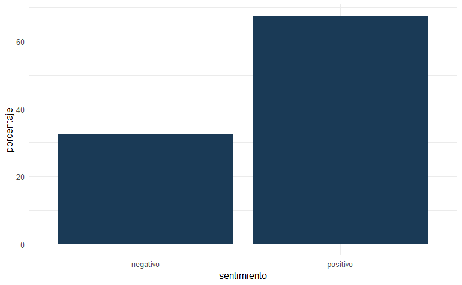

```r
castillosentiment %>%
        ggplot(aes(sentiment)) +
        geom_bar(aes(y = (..count..)/sum(..count..)*100),fill="#1a3a56") +
        xlab("sentimiento") +
        ylab("porcentaje") +
        theme_minimal()
```

Aproximadamente un 68% de las palabras que ha utilizado Pedro Cstillo son positivas, mientras el 32% son negativas.

Las palabras que más peso aportan a la positividad y negatividad son las siguientes:

```r
count_sent <- castillosentiment %>%
  count(word, sentiment, sort = TRUE) %>%
  ungroup()
count_sent
```

| word | sentiment | n |
| --- | --- | --- |
| pueblo | positivo | 214 |
| compromiso | positivo | 67 |
| saludo | positivo | 44 |
| justicia | positivo | 40 |
| apoyo | positivo | 35 |
| solidaridad | positivo | 35 |
| congreso | negativo | 33 |
| lograr | positivo | 31 |
| corrupcion | negativo | 30 |
| derechos | positivo | 29 |

[output cut: 757 more lines]

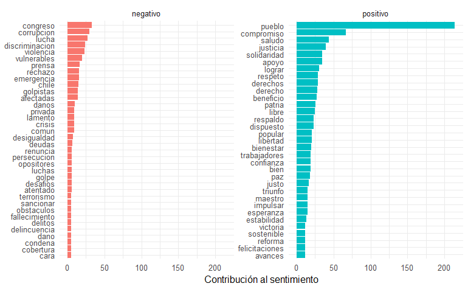

```r
#Graficamos
count_sent %>%
 group_by(sentiment) %>%
  top_n(30) %>%
  ungroup() %>%
  mutate(word = reorder(word, n)) %>%
  ggplot(aes(word, n, fill = sentiment)) +
  geom_col(show.legend = FALSE) +
  facet_wrap(~sentiment, scales = "free_y") +
  labs(y = "Contribución al sentimiento",
       x = NULL) +
  coord_flip() +
  theme_minimal()
```

Ahora crearemos un indice de sentimiento (*isent*) para ponderar la carga de positividad o negatividad en cada tweet. Para ello: $isent(t) = s / nw$ donde el indice de sentimiento para un tweet sera la proporción entre el numero de palabras con carga emocional $s$ dividido entre el total de palabras $nw$, excluyendo las palabras vacías. Crearemos un índice para cada polaridad:

```r
#Contamos el total de palabras negativas y positivas por tweets
library(tidyr)
tweets_sen <- castillosentiment %>%
  group_by(X) %>%
  count(sentiment)
castillovar_sent <- inner_join(castillovar, tweets_sen)
castillovar_sent <- spread(castillovar_sent, sentiment, n)
castillovar_sent[is.na(castillovar_sent)] <- 0
```

```r
#Limpiamos de las palabras vacias y las URL de la variable texto y la añadimos a nuestra tabla de datos
library(tm)
castillo_corpus <- (Corpus(VectorSource(castillovar_sent$text)))

corpus <- tm_map(castillo_corpus, removeWords, stopwords("spanish"))
removeURL <- function(x) gsub("http[[:alnum:][:punct:]]*", "", x)

corpus <- tm_map(corpus, content_transformer(removeURL))
text_c <- data.frame(text=sapply(corpus, identity),
    stringsAsFactors=F)
castillovar_sent <- bind_cols(castillovar_sent, text_c)
```

```r
#Contamos las palabras de cada tweet y calculamos los indices
castillovar_sent <- mutate(castillovar_sent, nw = str_count(castillovar_sent$text...3, "\\S+"))
castillovar_sent <- mutate(castillovar_sent, isent_neg =  (negativo / nw)*100)
castillovar_sent <- mutate(castillovar_sent, isent_pos =  (positivo / nw)*100)
castillovar_sent
```

| X | created_at | text...3 | favorite_count | retweet_count | negativo | positivo | text...8 | nw | isent_neg | isent_pos |
| --- | --- | --- | --- | --- | --- | --- | --- | --- | --- | --- |
| 3 | 2022-10-18 00:23:09 | El presidente @PedroCastilloTe inspecciono, de forma inopinada, el proyecto de mejoramiento de servicio de agua potable en zona Noroccidental de Cusco, que beneficiara a mas de 36 000 ciudadanos de la… | 0 | 52 | 0 | 1 | El presidente @PedroCastilloTe inspecciono, forma inopinada, proyecto mejoramiento servicio agua potable zona Noroccidental Cusco, beneficiara mas 36 000 ciudadanos region. | 33 | 0.000000 | 3.030303 |
| 4 | 2022-10-17 23:15:22 | Porque somos el gobierno del pueblo, trabajamos para que mas peruanos/as tengan agua potable. Hoy estuve en el Cusco inspeccionando el proyecto de mejoramiento de servicio de agua potable en zona Noro… | 840 | 154 | 0 | 2 | Porque gobierno pueblo, trabajamos mas peruanos/as agua potable. Hoy Cusco inspeccionando proyecto mejoramiento servicio agua potable zona Noroccidental, buscamos beneficio mas 36 000 ciudadanos regio… | 45 | 0.000000 | 4.444444 |
| 5 | 2022-10-17 21:01:06 | El proyecto de ley permitira mitigar la volatilidad de los precios internacionales para evitar que se trasladen a los consumidores finales. Ademas, se acordo respaldar a @petroperu_sa con un aporte ca… | 0 | 23 | 2 | 2 | El proyecto ley permitira mitigar volatilidad precios internacionales evitar trasladen consumidores finales. Ademas, acordo respaldar @petroperu_sa aporte capital fin reforzar capacidad financiera.\r\… | 41 | 4.878049 | 4.878049 |
| 6 | 2022-10-17 17:58:54 | Hoy mi hermosa e historica tierra natal cumple 129 anos de aniversario.Tacabamba, la "Sucursal del Cielo" la ciudad que me vio nacer y crecer , hoy celebra un ano mas de creacion politica, llena de tr… | 2991 | 351 | 1 | 3 | Hoy hermosa historica tierra natal cumple 129 anos aniversario.Tacabamba, "Sucursal Cielo" ciudad vio nacer crecer , hoy celebra ano mas creacion politica, llena tradiciones luchas.\r\nUn fraterno abr… | 47 | 2.127660 | 6.382979 |
| 7 | 2022-10-17 16:55:19 | El presidente @PedroCastilloTe, participo, de forma virtual, en el foro mundial de la alimentacion de la Organizacion de las Naciones Unidas para la Alimentacion y la Agricultura (FAO), donde destaco … | 0 | 125 | 0 | 1 | El presidente @PedroCastilloTe, participo, forma virtual, foro mundial alimentacion Organizacion Naciones Unidas Alimentacion Agricultura (FAO), destaco gobierno implementando Segunda Reforma Agraria. | 40 | 0.000000 | 2.500000 |
| 8 | 2022-10-16 23:00:50 | Presidente @PedroCastilloTe en ceremonia por el Dia Nacional de las Personas con Discapacidad: "Mi gobierno es consciente de la discriminacion que han vivido y conozco sus demandas. Ratifico mi compro… | 0 | 55 | 2 | 1 | Presidente @PedroCastilloTe ceremonia Dia Nacional Personas Discapacidad: "Mi gobierno consciente discriminacion vivido conozco demandas. Ratifico compromiso Ejecutivo revertirlo". | 36 | 5.555556 | 2.777778 |
| 9 | 2022-10-16 02:48:14 | !Gracias muchachos por dejar en alto el nombre del Peru!\r\nMis felicitaciones y reconocimiento a la delegacion peruana por las 74 medallas obtenidas: oro, plata y bronce en #ASU2022. Sus destrezas y … | 2747 | 342 | 0 | 3 | !Gracias muchachos dejar alto nombre Peru!\r\nMis felicitaciones reconocimiento delegacion peruana 74 medallas obtenidas: oro, plata bronce #ASU2022. Sus destrezas disciplina posiciona vez mas primero… | 45 | 0.000000 | 6.666667 |
| 10 | 2022-10-16 02:21:30 | !Alas de esperanza! Ministerio de Defensa (@MindefPeru) entrego 14 toneladas de ayuda humanitaria en Cusco https://t.co/vaPZBPm9h0 https://t.co/kXZJzKmWZD | 0 | 22 | 0 | 1 | !Alas esperanza! Ministerio Defensa (@MindefPeru) entrego 14 toneladas ayuda humanitaria Cusco | 17 | 0.000000 | 5.882353 |
| 11 | 2022-10-15 23:57:50 | El presidente de la Republica, @PedroCastilloTe superviso hoy el terreno que sera destinado para las obras de ampliacion y mejoramiento del Hospital de San Juan de Lurigancho que beneficiara a mas de … | 0 | 80 | 0 | 1 | El presidente Republica, @PedroCastilloTe superviso hoy terreno sera destinado obras ampliacion mejoramiento Hospital San Juan Lurigancho beneficiara mas 1 millon ciudadanos.\r\n#SiempreConElPueblo | 38 | 0.000000 | 2.631579 |
| 12 | 2022-10-15 21:18:13 | Seguimos trabajando para concretar esta importante obra en nuestra gestion de gobierno, lo cual permitira que mas de 10 millones de ciudadanos de Lima y Callao tengan un medio de transporte rapido y m… | 990 | 199 | 0 | 2 | Seguimos trabajando concretar importante obra gestion gobierno, permitira mas 10 millones ciudadanos Lima Callao medio transporte rapido moderno. | 35 | 0.000000 | 5.714286 |

[output cut: 930 more lines]

Ahora crearemos una variable nueva llamada *interact* que es simplemente la suma de de los favoritoss y retweets. Ello se justifica porque existe una fuerte correlación entre esos dos tipos de interacción.

```r
#Correlación entre los favs y los retweets
cor(castillovar_sent$favorite_count, castillovar_sent$retweet_count)
```

```
[1] 0.7395054
```

```r
#Creamos una nueva variable que es la interacción
castillovar_sent$interact <- castillovar_sent$favorite_count + castillovar_sent$retweet_count
castillovar_sent
```

| X | created_at | text...3 | favorite_count | retweet_count | negativo | positivo | text...8 | nw | isent_neg | isent_pos | interact |
| --- | --- | --- | --- | --- | --- | --- | --- | --- | --- | --- | --- |
| 3 | 2022-10-18 00:23:09 | El presidente @PedroCastilloTe inspecciono, de forma inopinada, el proyecto de mejoramiento de servicio de agua potable en zona Noroccidental de Cusco, que beneficiara a mas de 36 000 ciudadanos de la… | 0 | 52 | 0 | 1 | El presidente @PedroCastilloTe inspecciono, forma inopinada, proyecto mejoramiento servicio agua potable zona Noroccidental Cusco, beneficiara mas 36 000 ciudadanos region. | 33 | 0.000000 | 3.030303 | 52 |
| 4 | 2022-10-17 23:15:22 | Porque somos el gobierno del pueblo, trabajamos para que mas peruanos/as tengan agua potable. Hoy estuve en el Cusco inspeccionando el proyecto de mejoramiento de servicio de agua potable en zona Noro… | 840 | 154 | 0 | 2 | Porque gobierno pueblo, trabajamos mas peruanos/as agua potable. Hoy Cusco inspeccionando proyecto mejoramiento servicio agua potable zona Noroccidental, buscamos beneficio mas 36 000 ciudadanos regio… | 45 | 0.000000 | 4.444444 | 994 |
| 5 | 2022-10-17 21:01:06 | El proyecto de ley permitira mitigar la volatilidad de los precios internacionales para evitar que se trasladen a los consumidores finales. Ademas, se acordo respaldar a @petroperu_sa con un aporte ca… | 0 | 23 | 2 | 2 | El proyecto ley permitira mitigar volatilidad precios internacionales evitar trasladen consumidores finales. Ademas, acordo respaldar @petroperu_sa aporte capital fin reforzar capacidad financiera.\r\… | 41 | 4.878049 | 4.878049 | 23 |
| 6 | 2022-10-17 17:58:54 | Hoy mi hermosa e historica tierra natal cumple 129 anos de aniversario.Tacabamba, la "Sucursal del Cielo" la ciudad que me vio nacer y crecer , hoy celebra un ano mas de creacion politica, llena de tr… | 2991 | 351 | 1 | 3 | Hoy hermosa historica tierra natal cumple 129 anos aniversario.Tacabamba, "Sucursal Cielo" ciudad vio nacer crecer , hoy celebra ano mas creacion politica, llena tradiciones luchas.\r\nUn fraterno abr… | 47 | 2.127660 | 6.382979 | 3342 |
| 7 | 2022-10-17 16:55:19 | El presidente @PedroCastilloTe, participo, de forma virtual, en el foro mundial de la alimentacion de la Organizacion de las Naciones Unidas para la Alimentacion y la Agricultura (FAO), donde destaco … | 0 | 125 | 0 | 1 | El presidente @PedroCastilloTe, participo, forma virtual, foro mundial alimentacion Organizacion Naciones Unidas Alimentacion Agricultura (FAO), destaco gobierno implementando Segunda Reforma Agraria. | 40 | 0.000000 | 2.500000 | 125 |
| 8 | 2022-10-16 23:00:50 | Presidente @PedroCastilloTe en ceremonia por el Dia Nacional de las Personas con Discapacidad: "Mi gobierno es consciente de la discriminacion que han vivido y conozco sus demandas. Ratifico mi compro… | 0 | 55 | 2 | 1 | Presidente @PedroCastilloTe ceremonia Dia Nacional Personas Discapacidad: "Mi gobierno consciente discriminacion vivido conozco demandas. Ratifico compromiso Ejecutivo revertirlo". | 36 | 5.555556 | 2.777778 | 55 |
| 9 | 2022-10-16 02:48:14 | !Gracias muchachos por dejar en alto el nombre del Peru!\r\nMis felicitaciones y reconocimiento a la delegacion peruana por las 74 medallas obtenidas: oro, plata y bronce en #ASU2022. Sus destrezas y … | 2747 | 342 | 0 | 3 | !Gracias muchachos dejar alto nombre Peru!\r\nMis felicitaciones reconocimiento delegacion peruana 74 medallas obtenidas: oro, plata bronce #ASU2022. Sus destrezas disciplina posiciona vez mas primero… | 45 | 0.000000 | 6.666667 | 3089 |
| 10 | 2022-10-16 02:21:30 | !Alas de esperanza! Ministerio de Defensa (@MindefPeru) entrego 14 toneladas de ayuda humanitaria en Cusco https://t.co/vaPZBPm9h0 https://t.co/kXZJzKmWZD | 0 | 22 | 0 | 1 | !Alas esperanza! Ministerio Defensa (@MindefPeru) entrego 14 toneladas ayuda humanitaria Cusco | 17 | 0.000000 | 5.882353 | 22 |
| 11 | 2022-10-15 23:57:50 | El presidente de la Republica, @PedroCastilloTe superviso hoy el terreno que sera destinado para las obras de ampliacion y mejoramiento del Hospital de San Juan de Lurigancho que beneficiara a mas de … | 0 | 80 | 0 | 1 | El presidente Republica, @PedroCastilloTe superviso hoy terreno sera destinado obras ampliacion mejoramiento Hospital San Juan Lurigancho beneficiara mas 1 millon ciudadanos.\r\n#SiempreConElPueblo | 38 | 0.000000 | 2.631579 | 80 |
| 12 | 2022-10-15 21:18:13 | Seguimos trabajando para concretar esta importante obra en nuestra gestion de gobierno, lo cual permitira que mas de 10 millones de ciudadanos de Lima y Callao tengan un medio de transporte rapido y m… | 990 | 199 | 0 | 2 | Seguimos trabajando concretar importante obra gestion gobierno, permitira mas 10 millones ciudadanos Lima Callao medio transporte rapido moderno. | 35 | 0.000000 | 5.714286 | 1189 |

[output cut: 930 more lines]

Por ultimo graficaremos y calcularemos la relación entre el indice de sentimiento y la interacción:

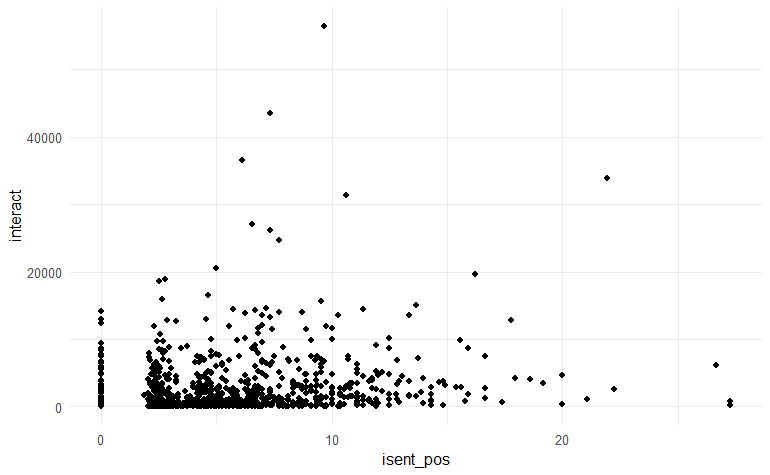

```r
castillovar_sent %>%
  ggplot() +
  aes(x = isent_pos, y = interact) +
  geom_point() +
  theme_minimal()
```

```r
cor(castillovar_sent$isent_pos, castillovar_sent$interact) #correlación
```

```
[1] 0.1795327
```

```r
regpos <- lm(interact ~ isent_pos, castillovar_sent) #regresion lineal
summary(regpos)
```

```
Call:
lm(formula = interact ~ isent_pos, data = castillovar_sent)

Residuals:
   Min     1Q Median     3Q    Max
 -6801  -2137  -1446    418  52853

Coefficients:
            Estimate Std. Error t value Pr(>|t|)
(Intercept)  1594.86     240.88   6.621 6.00e-11 ***
isent_pos     198.60      35.53   5.589 2.99e-08 ***
---
Signif. codes:  0 ‘***’ 0.001 ‘**’ 0.01 ‘*’ 0.05 ‘.’ 0.1 ‘ ’ 1

Residual standard error: 4470 on 938 degrees of freedom
Multiple R-squared:  0.03223,   Adjusted R-squared:  0.0312
F-statistic: 31.24 on 1 and 938 DF,  p-value: 2.988e-08
```

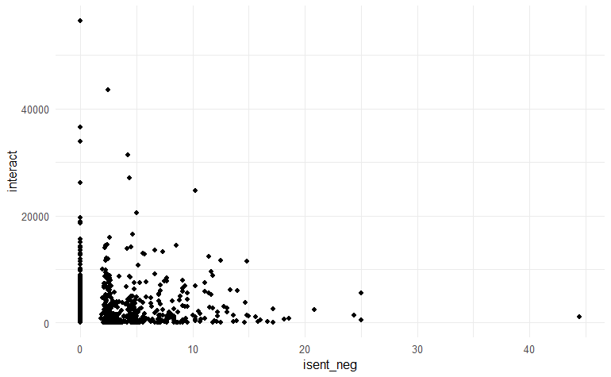

```r
castillovar_sent %>%
  ggplot() +
  aes(x = isent_neg, y = interact) +
  geom_point() +
  theme_minimal()
```

```r
cor(castillovar_sent$isent_neg, castillovar_sent$interact)#correlación
```

```
[1] 0.02045306
```

```r
regneg <- lm(interact ~ isent_neg, castillovar_sent) #regresion lineal
summary(regneg)
```

```
Call:
lm(formula = interact ~ isent_neg, data = castillovar_sent)

Residuals:
   Min     1Q Median     3Q    Max
 -3001  -2474  -1611    592  53767

Coefficients:
            Estimate Std. Error t value Pr(>|t|)
(Intercept)  2602.95     179.64  14.489   <2e-16 ***
isent_neg      23.33      37.23   0.627    0.531
---
Signif. codes:  0 ‘***’ 0.001 ‘**’ 0.01 ‘*’ 0.05 ‘.’ 0.1 ‘ ’ 1

Residual standard error: 4543 on 938 degrees of freedom
Multiple R-squared:  0.0004183, Adjusted R-squared:  -0.0006473
F-statistic: 0.3926 on 1 and 938 DF,  p-value: 0.5311
```

## Conclusión

La polaridad general de los tweets de la cuenta de Pedro Castillo apunta a un mayor uso de palabras positivas (68%) que negativas (32%). En la relación entre la polaridad de los tweets y la interacción, podemos encontrar una diferencia entre la recepción de los tweets positivos y los negativos. Los tweets positivos tienen una mayor interacción que los negativos, en la prueba de correlación los tweets positivos obtienen un 0,18 mientras los negativos tan sólo 0,02. Pasando a la prueba de regresión, los tweets por cada punto porcentual positivo reciben en promedio 199 interacciones más, con un p-valor significativo; mientras que los puntos porcentuales negativo no tiene el mismo efecto, consiguiendo 23 interacciones más, pero con un p-valor no significativo.

Lo anterior puede ilustrarse con el análisis de los diez tweets con mayor interacción:

```r
pop_t <- castillovar_sent %>%
        select(text...3, interact, isent_neg, isent_pos) %>%
        arrange(desc(interact))
head(pop_t, n = 10) %>% knitr::kable()
```

[output not shown]